# 神经网络的矩阵形式

### 1. 我们为什么要把神经网络表示成矩阵乘法的形式？

在上节课的末尾，我们学会了如何通过计算在一个极为简化的神经网络中追踪信号。

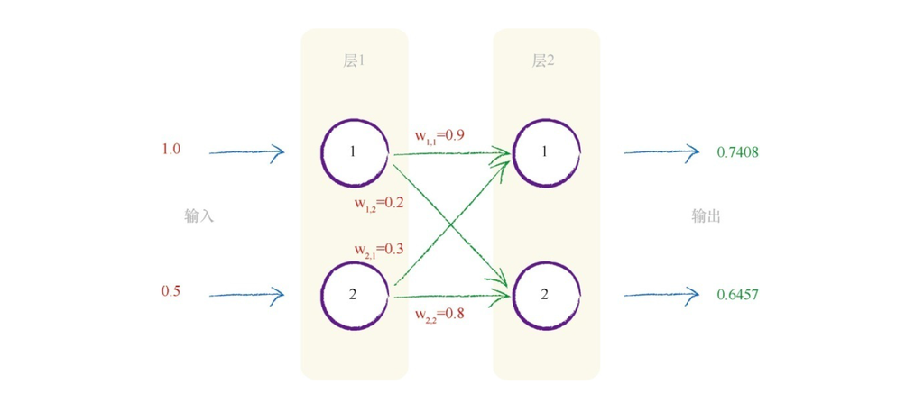

我们可以算出第二层第2个节点的输入 x 为：

$$ x = （1.0 * 0.2） + （0.5 * 0.8） = 0.6 $$

然后把x代入到S函数（激活函数）当中，得到：

$$ y=\dfrac {1}{1+e^{-0.6}} = 0.6457 $$

这只是一个2层的神经网络，每一层只有2个神经元，因此计算每个神经元的输入输出相对来说比较容易，工作量较小。

对于更加复杂的神经网络，比如说，4层神经元，每一层有100个节点...的网络，计算每一个神经元的输入与输出会是一项很艰苦的工作。

我们当然可以编写程序让计算机来执行这样的操作。就像上节课的末尾我们所做的那样。毕竟计算机对于给定程序的大量计算乐此不疲。

然而即使只是写出所有层次和节点的计算指令，也会十分枯燥。

...因为要对每一层每一个节点，计算所有这些组合信号的组合，乘以正确的权重，应用S激活函数...

好在，即使是面对一个具有很多层、众多节点的神经网络，数学可以帮助我们以非常简洁的方式写下计算出所有输出值的指令。

这就需要使用一种重要的，让人闻风丧胆的数学工具：矩阵乘法。

矩阵是一个工具，

它可以应用的场景有很多，如：

```
线性变换；
线性方程（很多教材都是从这里开始写矩阵的）；
用于表示一些代数；
排列数（permutation）；
可达性（图论）；
以及很多应用上，比如层次分析法中的比较矩阵、神经网络中数据传递的过程等等。
```

面对看上去很恐怖的矩阵，我们

#### 不要恐慌！不要害怕！面对困难最好的方法就是战胜它！

[figure not shown]

我们拒绝使用线性代数教材上对于矩阵乘法的各种定义。

就让小明现身说法，为我们演示一遍矩阵乘法怎么乘，以及，能干什么。

### 2. 小明与矩阵乘法

小明今天要做饭，消耗2斤肉，1斤蔬菜。肉每斤20元，蔬菜每斤5元，请问一共需多少花费？

这个问题的答案很简单：

$$ 20*2 + 5*1 = 45 $$

上面这个式子，可以用这种方式写出来：

$$ \begin{pmatrix} 20 & 5 \end{pmatrix}\begin{pmatrix} 2 \\ 1 \end{pmatrix}=45 $$

左边括号里的一行，就是肉和蔬菜的价格。右边括号里的一列，就是肉和蔬菜的消耗。

我们把括号里的东西当成是一个“矩阵”，那么上面这个式子可以看做2个矩阵相乘。

这2个矩阵相乘的计算就是用左边一行乘以右边一列对应的数值，再相加。

这就是矩阵乘法啦！

如果小明第二天有另一种做饭的方法，需要消耗1斤肉，4斤蔬菜，那么这两种方法的花费各是多少呢？

我们把第二种做饭方式写在第二个矩阵里，作为第二列：

$$ \begin{pmatrix} 20 & 5 \end{pmatrix}\begin{pmatrix} 2 & 1 \\ 1 & 4 \end{pmatrix}=\begin{pmatrix} 45 & 40 \end{pmatrix} $$

可以看到，这2个矩阵相乘的计算，是用第一个矩阵第一行的2个数分别乘以第二个矩阵的第一列的2个数，再相加，得到45；然后用第一个矩阵的第一行分别乘以第二个矩阵的第二列，再相加，得40。

小明家附近还有另一个菜市场，那里肉每斤15元，蔬菜每斤10元。

那么，小明如果去这个菜市场，花费又是多少呢（分别计算上述两种做饭方式）？

我们把这另外的一种价格写进第一个矩阵里，作为第二行：

$$ \begin{pmatrix} 20 & 5 \\ 15 & 10 \end{pmatrix}\begin{pmatrix} 2 & 1 \\ 1 & 4 \end{pmatrix}=\begin{pmatrix} 45 & 40 \\ 40 & 55 \end{pmatrix} $$

请你自己核验一遍这2个矩阵相乘的结果。

这样我们看到了一个矩阵乘法的例子。

在左边的这个矩阵的每一行，都代表了一种价目表；

在右边的矩阵的每一列，都代表了一种做饭方式。

那么所有可能的组合所最终产生的花费，则在结果矩阵中表示出来了。

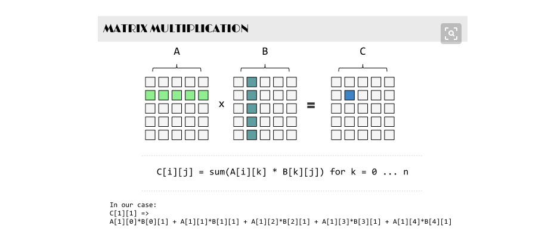

这就是矩阵乘法的方法（和意义）。在一些书籍中，你会看到这样的矩阵乘法称为点乘（dot product）或内积（inner product）。实际上，对于矩阵而言，有不同类型的乘法，如叉乘，但是我们此处所指的是点乘。

#### 注意！A矩阵和B矩阵可以相乘的条件是：A矩阵的列数等于B矩阵的行数。矩阵的乘法不满足交互律，即A X B != B X A。

##### （对于矩阵乘法这种解释方法，源于一位知乎作者翡翠衾寒，原文链接：https://www.zhihu.com/question/21351965/answer/31050145）

小明决定编写python代码来实现矩阵乘法运算，来计算不同的菜市场和不同的菜谱所最终产生花费的组合。

```python
import numpy as np

#定义矩阵A ：每一行为不同菜市场的菜价
A = np.array([[20,5],[15,10]])

#定义矩阵B ： 每一列为不同的菜谱
B = np.array([[2,1],[1,4]])

#计算价目表：矩阵A乘以矩阵B
C = np.dot(A,B)

print(C)
```

[output not shown]

### 3. 见证奇迹的时刻

矩阵乘法这种东西除了帮助小明成为会写python代码的厨子，还可以做什么呢？

我们来看一看下面这个矩阵乘法：

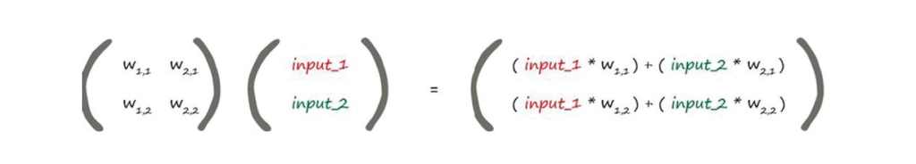

你是否有一种豁然开朗，拨云见日的感觉？

见证奇迹的时刻到来了！

上面的第一个矩阵包含两层神经元之间的权重。第二个矩阵包含第一层（输入层）的信号。

通过两个矩阵相乘，我们得到的答案不是别的，正是第二层神经元接收到的输入信号。

（由权重w1,1 调节的input_1加上由权重w2,1 调节的input_2，就是第二层第一个节点的输入值。）

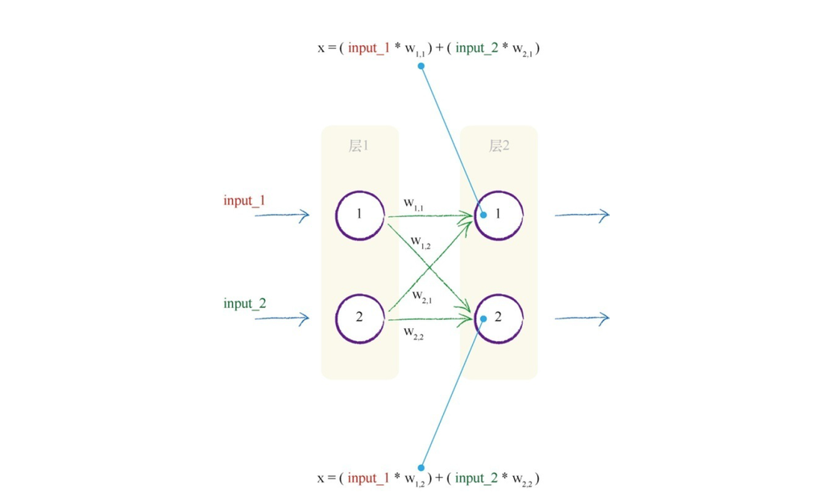

我们把这个输入值作为x套用S激活函数，就能得到这个节点的输出。

这真的是非常有用啊！

因为我们可以用 *W* 来表示左侧的权重矩阵，用 *I* 来表示右侧的输入矩阵，用 *X* 来表示输入到第二层神经元的信号矩阵。

而第二层的输入矩阵就可以表示成：

$$ \textit{X = W · I }$$

#### 矩阵通常使用斜体显示，表示它们是矩阵，而不是单个数字。

现在，我们不需要在乎每一层有多少个节点。我们可以简单地写为*W •I* ，不管I有2个元素还是有200个元素。

对于第二层神经元，我们既然已经能够表示它的输入矩阵 *X* ，就可以对这个输入矩阵直接套用S函数（意思是对输入矩阵中的每一个元素分别套用S函数），得到输出矩阵 *O*。正如我们先前看到的，激活函数只是简单地应用阈值，使反应变得更像是在生物神经元中观察到的行为。（见上一讲）

因此，来自第二层的输出是：

$$ \textit{ O } = sigmoid( \textit{ X }) $$

表达式 $ \textit{X = W · I }$ 适用于前后层之间的计算。比如说，我们有3层，我们简单地再次进行矩阵乘法，使用第二层的输出作为第三层的输入。

现在让我们看一个稍微复杂一点的例子。我们将使用3层、每一层有3个节点的神经网络。

### 4. 在神经网络中用python实现矩阵乘法

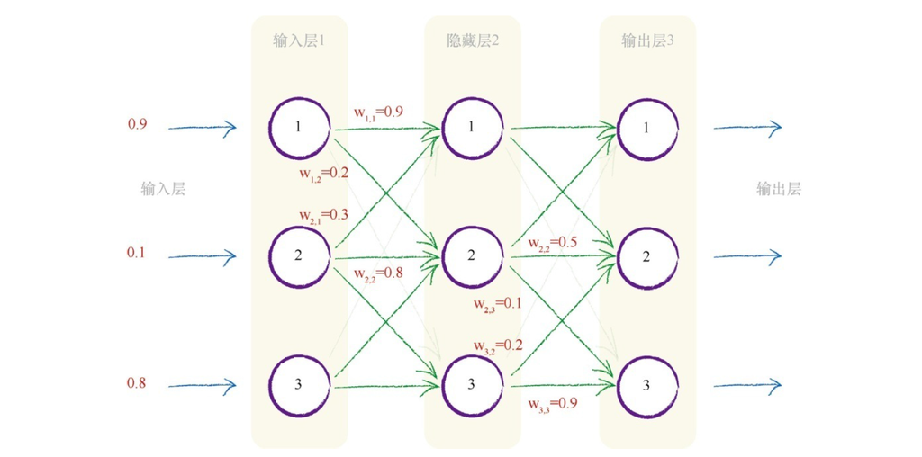

这是一个3 * 3 的神经网络。（权重并没有完全标出）

在这个网络中，我们将第一层称之为输入层，最后一层为输出层，中间层为隐藏层。

我们将给这个神经网络一个输入：

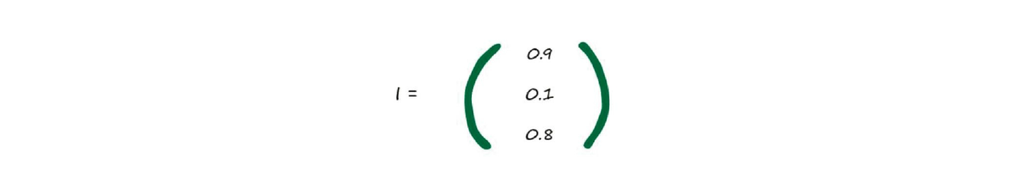

这个输入矩阵 *I* ， 以及以下的输入层到隐藏层的链接权重矩阵 $ W_{ input-hidden } $, 隐藏层到输出层的链接权重矩阵 $ W_{ hidden-output } $都没有什么特殊的意义，全是编的，随机的。

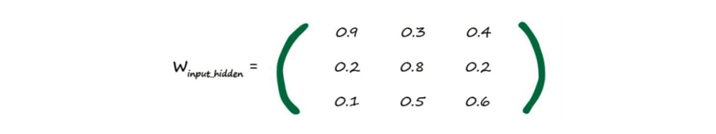

上面这个输入层到隐藏层的链接权重矩阵 $ W_{ input-hidden } $ 是什么意思呢？它表示：

输入层的第一节点和中间隐藏层第一个节点之间的权重为 W（1,1） = 0.9 输入层的第二节点和隐藏层的第二节点之间的链接的权重为W（2,2 ）= 0.8 ...

就是这样。

如此一来，我们就可以根据以下的矩阵乘法公式，计算中间隐藏层的输入 $ X_{hidden} $

$$ X_{hidden}=W_{ input-hidden }\cdot I $$

计算的结果为：

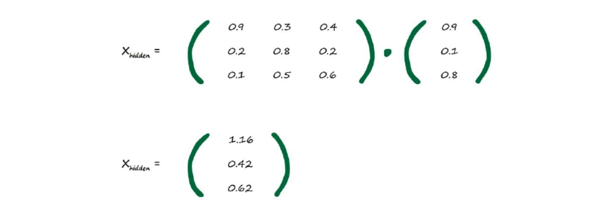

接下来，我们再通过下面的式子把输入代入到S函数当中，得到隐藏层的输出 $ O_{hidden} $

$$ O_{hidden} = sigmoid( X_{hidden}) $$

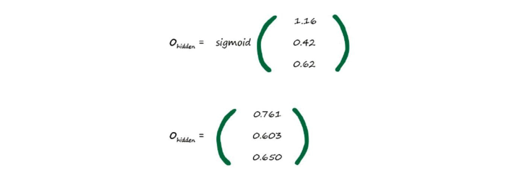

以上过程用python写出来，就是：

```python
import numpy as np
import scipy.special

#定义输入层的输入矩阵I ：
I = np.array([[0.9],[0.1],[0.8]])

#定义输入层到隐藏层的链接矩阵W_input_hidden ：
W_input_hidden = np.array([[0.9,0.3,0.4],[0.2,0.8,0.2],[0.1,0.5,0.6]])

#计算隐藏层的输入矩阵 = 矩阵W_input_hiddwn 点乘 矩阵I
X_hidden = np.dot(W_input_hidden,I)

#计算隐藏层的输出矩阵 = 将sigmod函数作用到隐藏层的输入矩阵X_hidden上。
O_hidden = scipy.special.expit(X_hidden)

#输出结果
print("隐藏层的输入矩阵为")
print(X_hidden)

print("隐藏层的输出矩阵为")
print(O_hidden)
```

[output not shown]

如果这只是一个两层的神经网络，那么这些就是第二层的输出值，我们现在就可以停止计算了。

但是，由于还有第三层，我们不能在此处停止计算。

我们如何处理通过第三层的信号呢？

我们可以采用与处理第二层信号相同的方式进行处理，这没有任何实质的区别。

为了从第二层的输出信号得到第三层的输入信号，我们还需要第二层到第三层的链接权重：

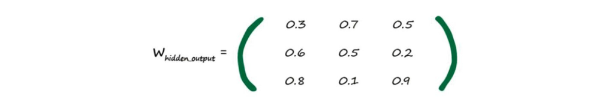

现在。

请同学们仿照上面的计算过程和python示例，

计算第三层（输出层）的输入矩阵和输出矩阵。（别懒，自己打一遍！）

```python
import numpy as np
import scipy.special

#定义隐藏层的输出矩阵O_hidden：


#定义隐藏层到输出层的链接矩阵W_hidden_output：


#计算输出层的输入矩阵 X_outputs = 矩阵W_hidden_output 点乘 矩阵O_hidden


#计算输出层的输出矩阵 O_outputs = 将sigmod函数作用到隐藏层的输入矩阵X_outputs上。


#输出结果
print("输出层的输入矩阵为")
print(X_outputs)

print("输出层的输出矩阵为")
print(O_outputs)
```

现在我们已经得到了神经网络的最终输出信号！

这是个了不起的成就！

下面，我们将会学习如何将这个（链接权重随机的）神经网络的最终输出信号与训练样品中的输出信号进行比较，利用误差值来调整神经网络的链接权重，进而将输出值改进得更接近训练样本。

## 本讲要点

1. 矩阵乘法的方法和意义。
2. 通过神经网络传递信号所需的大量运算可以表示为矩阵乘法。
3. 矩阵乘法的python语言实现。